# Single Cell Intergration

Anna K. Casasent, PhD

2024-12-01

# Introduction

Single-cell RNA sequencing (scRNA-seq) has revolutionized our ability to study complex biological systems at unprecedented resolution. However, as datasets grow larger and more complex, researchers face significant challenges in integrating and analyzing data from multiple sources. This tutorial aims to guide you through advanced techniques for scRNA-seq data analysis, with a focus on integration methodologies and quality assessment. Drawing from my experience in cancer genomics and computational biology, we’ll explore key steps in a modern scRNA-seq analysis workflow:

[output not shown]

We’ll use renal data from the CellxGene database as our example dataset. This choice allows us to work with clinically relevant data that presents common challenges in single-cell analysis, such as batch effects and tumor heterogeneity.

The goal is this tutorial is to give you have a solid understanding of:

[output not shown]

Note: I will devote most of the lecture to the integration methods and assessing integration – is it needed and did it work.

Hopefully, this will empower you to tackle complex single-cell projects with confidence, whether you’re studying cancer genomics, developmental biology, or other areas of biomedical research.

# Data Preparation

In this section, we prepare our environment and load the necessary libraries for single-cell RNA sequencing (scRNA-seq) data analysis.

Each library serves a specific purpose in our workflow.

These libraries are crucial for our analysis pipeline in the following ways:

```
cellxgenedp allows us to directly access and download data from the CellxGene portal, simplifying data acquisition.
Seurat is the core package for scRNA-seq analysis, providing functions for data normalization, dimensionality reduction, clustering, and visualization.
harmony is used for batch effect correction and data integration, which is essential when working with multiple datasets or samples.
ggplot2 and patchwork are used for creating publication-quality visualizations of our data and results.
dplyr provides efficient data manipulation functions that we'll use throughout our analysis.
biomaRt is used to convert gene identifiers, specifically from Ensembl IDs to HUGO gene symbols, making our data more interpretable.
cluster, fpc, and clusterSim provide functions for cluster analysis and validation, which we'll use to evaluate our clustering results.
fields and lisi are used for calculating the Local Inverse Simpson's Index, a metric for assessing integration quality.
kneedle helps in determining the optimal number of principal components to use in our analysis.
```

By loading these libraries at the beginning of our script, we ensure that all the necessary functions are available for our subsequent analysis steps.

While there are many other different tools we could use, we selected tools that are more robust and commonly used in single cell sequencing analysis in R.

```r
library(cellxgenedp)
# Provides an R interface for discovering, viewing, and downloading single-cell data from the CELLxGENE data portal.
# Reference: https://bioconductor.org/packages/cellxgenedp/

library(Seurat)
# A toolkit for quality control, analysis, and exploration of single-cell RNA sequencing data.
# Reference: https://satijalab.org/seurat/

library(harmony)
```

```r
# Used for integrating multiple single-cell datasets and correcting batch effects.
# Reference: https://github.com/immunogenomics/harmony

library(ggplot2)
# A system for declaratively creating graphics, based on The Grammar of Graphics.
# Reference: https://ggplot2.tidyverse.org/

library(patchwork)
# Simplifies the process of combining multiple ggplots into one graphic.
# Reference: https://patchwork.data-imaginist.com/

library(dplyr)
# A grammar of data manipulation, providing a consistent set of verbs to help solve data manipulation challenges.
# Reference: https://dplyr.tidyverse.org/

library(biomaRt)
# Provides an interface to BioMart databases (e.g., Ensembl, COSMIC, Wormbase and Gramene).
# Reference: https://bioconductor.org/packages/release/bioc/html/biomaRt.html

library(cluster)
# Provides functions for cluster analysis, including calculating silhouette scores.
# Reference: https://cran.r-project.org/web/packages/cluster/index.html

library(fpc)
# Flexible procedures for clustering, including various clustering algorithms and cluster validation statistics.
# Reference: https://cran.r-project.org/web/packages/fpc/index.html

library(fields)
# Contains tools for spatial data and functions for spline fitting and kriging.
# Reference: https://cran.r-project.org/web/packages/fields/index.html

library(lisi)
# Implements the Local Inverse Simpson's Index (LISI) to assess the mixing of cells across categorical variables in single-cell datasets.
# Reference: https://github.com/immunogenomics/LISI

library(kneedle)
# Provides a method for finding the elbow point using the "knee" method.
# Reference: https://github.com/etam4260/kneedle

library(clusterSim)
# Searching for optimal clustering procedures for a dataset.
# Reference: https://cran.r-project.org/web/packages/clusterSim/index.html
```

# Load the CellxGene dataset

This section demonstrates how to access and download single-cell RNA sequencing data from the CellxGene database.

## Set base directories

This code sets up the base directory for the workshop and creates a subdirectory for data storage. Adjust the base directory path as needed for your system.

```r
chr_base_dir <- "C:/Users/akc/Desktop/workshop"
chr_dest_dir <- paste(chr_base_dir,"data", sep = "/")
```

## CellxGene database

This creates a connection to the CELLxGENE data portal. The db() function from the cellxgenedp package initializes the database connection, allowing us to query and access datasets.

```r
# Create a connection to the CELLxGENE data portal
obj_cxg_db <- db()
```

### Find dataset

This code filters the datasets from the CELLxGENE data portal based on several criteria:

```
Title contains "cancer"
Suspension type contains "cell"
Organism is "Homo sapiens"
Assay includes "10x" (likely referring to 10x Genomics technology)
Is primary data
Donor ID contains a comma (suggesting multiple donors)
Published on April 26, 2023
Cell count is less than 10,000
```

The resulting dataset IDs are printed.

```r
# Filter datasets from the CELLxGENE data portal based on specific criteria
tbl_filtered_db <- datasets(obj_cxg_db) %>%
  filter(grepl("cancer", title, ignore.case = TRUE),
         grepl("cell", suspension_type, ignore.case = TRUE),
         grepl("Homo sapien", organism, ignore.case = TRUE),
         grepl("10x", assay, ignore.case = TRUE),
         sapply(is_primary_data, function(x) any(x == TRUE | x == "TRUE")),
         grepl(",", donor_id),
         grepl("2023-04-26", published_at),
         cell_count < 10000)

# prints out the name of the ids that we have selected based on this info
print(tbl_filtered_db$dataset_id)
```

```
## [1] "f801b7a9-80a6-4d09-9161-71474deb58ae"
```

## Get the file information for the dataset

This code retrieves file information for the filtered datasets:

```
tbl_dataset_files contains all files associated with the filtered datasets.
tbl_rds_file specifically selects the RDS file from the dataset files.

Note that the rds file format will be remove in later this month and items will need to be processed from the H5AD data instead.
```

The RDS file is then used for downloading and loading the single-cell data into R for further analysis.

```r
# Retrieve files associated with the filtered datasets
tbl_dataset_files <- files(obj_cxg_db) %>% filter(dataset_id %in% tbl_filtered_db$dataset_id)
```

## Find the rds file

```r
# Extract H5AD and RDS file information from the dataset files
# tbl_h5ad_file  <- tbl_dataset_files %>% filter(filetype == "H5AD")
# h5ad_path <- download_files(tbl_h5ad_file)

tbl_rds_file <- tbl_dataset_files %>% filter(filetype == "RDS")
```

```r
# Create the directory if it does not exist
if (!dir.exists(chr_dest_dir)) {
    dir.create(chr_dest_dir, recursive = TRUE)
}

# get the file path for where you have downloaded the data.
chr_rds_file_path <- paste(chr_dest_dir, basename(tbl_rds_file$url), sep = "/")
```

## Load the RDS file

Here we load the RDS file.

```r
# read the seurat object
obj_seurat  <- readRDS(chr_rds_file_path)
```

# Ensembl

In single-cell RNA sequencing analysis, converting gene identifiers from Ensembl IDs to more familiar HUGO gene symbols is a crucial step for improved interpretability. This section outlines the process of connecting to the Ensembl database and retrieving HUGO gene symbols for our dataset.

## Connect to Ensembl Database

First, we create a function to establish a connection to the Ensembl database.

This function attempts to connect to different Ensembl mirrors with a retry mechanism to ensure robust connectivity.

```r
# Increase the timeout limit
options(timeout = 300)  # Set timeout to 5 minutes

# Function to connect to Ensembl with retry mechanism
connect_to_ensembl <- function(max_attempts = 3, mirrors = c("useast", "uswest", "asia")) {
  if (!requireNamespace("biomaRt", quietly = TRUE)) {
    stop("biomaRt package is not installed. Please install it using BiocManager::install('biomaRt')")
  }
  library(biomaRt)

  for (attempt in 1:max_attempts) {
    for (mirror in mirrors) {
      tryCatch({
        ensembl <- useEnsembl(biomart = "genes",
                              dataset = "hsapiens_gene_ensembl",
                              mirror = mirror)
        return(ensembl)
      }, error = function(e) {
        message(sprintf("Attempt %d failed for mirror %s: %s", attempt, mirror, e$message))
      })
    }
    if (attempt < max_attempts) Sys.sleep(15) # Wait 15 seconds before retrying
  }
  stop("Failed to connect to Ensembl after all attempts")
}
```

## Retrieve HUGO Gene Symbols

Next, we use the established connection to retrieve HUGO gene symbols for our Ensembl IDs:

```r
# Get the Ensembl IDs from the Seurat object
chr_ensembl_ids <- rownames(obj_seurat)

# Connect to the Ensembl database with retry mechanism
obj_ensembl <- connect_to_ensembl()

# Retrieve HUGO gene symbols
tbl_gene_symbols  <- getBM(attributes = c("ensembl_gene_id", "hgnc_symbol"),
                      filters = "ensembl_gene_id",
                      values = chr_ensembl_ids,
                      mart = obj_ensembl)
```

## Map Ensembl IDs to HUGO Symbols

We then create a mapping between Ensembl IDs and HUGO symbols.

Here we take the vector of the Hugo terms. Then we convert it. Note that we don’t have all the terms covered. Therefore, we will map to the initial Ensembl ids if the Hugo term was an empty vector.

```r
# Create a named vector for easy mapping
vec_id_map <- setNames(tbl_gene_symbols$hgnc_symbol, tbl_gene_symbols$ensembl_gene_id)

# Replace Ensembl IDs with HUGO symbols in the Seurat object
chr_new_rownames <- vec_id_map[rownames(obj_seurat)]
chr_new_rownames[which(chr_new_rownames == "")] <- rownames(obj_seurat)[which(chr_new_rownames == "")]
chr_new_rownames[is.na(chr_new_rownames)] <- rownames(obj_seurat)[is.na(chr_new_rownames)]
chr_new_rownames <- make.unique(chr_new_rownames)
```

## Update Seurat Object

Here we adjust the Seurat object because it will not let you rename items just by reassigning.

Finally, we update our Seurat object with the new HUGO gene symbols:

```r
# Create a new Seurat object with renamed features
obj_new_seurat <- obj_seurat

# Update the RNA assay
mat_new_counts <- LayerData(obj_seurat, assay = "RNA", layer = "counts")
mat_new_data <- LayerData(obj_seurat, assay = "RNA", layer = "data")
rownames(mat_new_counts) <- chr_new_rownames
rownames(mat_new_data) <- chr_new_rownames
obj_new_seurat[["RNA"]] <- CreateAssayObject(counts = mat_new_counts)
obj_new_seurat[["RNA"]] <- SetAssayData(obj_new_seurat[["RNA"]], layer = "data", new.data = mat_new_data)

# Transfer other important slots
obj_new_seurat@reductions <- obj_seurat@reductions
obj_new_seurat@graphs <- obj_seurat@graphs
obj_new_seurat@neighbors <- obj_seurat@neighbors

# Set the default assay
DefaultAssay(obj_new_seurat) <- DefaultAssay(obj_seurat)

obj_old_seurat <- obj_seurat
obj_seurat <- obj_new_seurat
```

This process ensures that our gene identifiers are now in the more familiar HUGO format, facilitating easier interpretation of results in downstream analyses.

# Basic Preprocessing

This section outlines essential preprocessing steps for single-cell RNA sequencing (scRNA-seq) data using the Seurat package. These steps are crucial for preparing the data for downstream analyses and ensuring robust results.

This code performs standard preprocessing steps for single-cell RNA sequencing data using the Seurat package:

```
NormalizeData(): This function normalizes the gene expression measurements for each cell by the total expression, multiplies by a scale factor (10,000 by default), and log-transforms the result.
FindVariableFeatures(): Identifies the most variable genes across the dataset. It uses the "vst" (variance stabilizing transformation) method to select the top 2000 variable features.
ScaleData(): Scales and centers the expression values for each gene, which is crucial for downstream analyses like PCA.
RunPCA(): Performs Principal Component Analysis on the scaled data, computing 50 principal components. PCA is used for dimensionality reduction and to capture the main sources of variation in the dataset.
```

```r
# Normalize the data
obj_seurat <- NormalizeData(obj_seurat)

# Identify highly variable features
obj_seurat <- FindVariableFeatures(obj_seurat, selection.method = "vst", nfeatures = 2000)

# Scale the data
obj_seurat <- ScaleData(obj_seurat)
# Perform Principal Component Analysis (PCA)
int_dim <- 50
obj_seurat <- RunPCA(obj_seurat, npcs = int_dim)
```

```
## PC_ 1
## Positive:  TM4SF1, NHERF2, IFI27, EPAS1, HLA-E, TIMP3, SOCS3, JUNB, RAMP2, PLPP1
##     GNG11, SPARC, A2M, RNASE1, ID1, CDKN1A, ENG, EMCN, FLT1, IRF1
##     IGFBP5, MEIS2, CRIP2, GSN, BST2, CAVIN2, PTPRB, KLF2, TCF4, PCAT19
## Negative:  ALDOB, SPP1, CXCL14, APOE, GATM, HPD, MT1G, GSTA1, FABP1, DCXR
##     MT1H, MIOX, BBOX1, PCK1, UGT2B7, GPX3, NAT8, BHMT, PCSK1N, PRAP1
##     GSTA2, FBP1, APOM, GLYATL1, PRODH2, SLC22A8, DPEP1, CTXN3, HAO2, ALB
## PC_ 2
## Positive:  ALDOB, GPX3, GATM, GSTA1, FABP1, HPD, MIOX, MT2A, MT1G, HLA-DRB1
##     HLA-DRA, SRGN, MT1H, HLA-DPA1, NAT8, PRAP1, CD74, HLA-DPB1, GSTA2, GMFG
##     HLA-DRB5, UGT2B7, BHMT, BBOX1, FBP1, APOM, IGFBP4, PRODH2, CTXN3, GLYATL1
## Negative:  MAL, CD24, CA12, CLDN4, ELF3, DEFB1, TMEM213, CLCNKB, TNFRSF12A, CKB
##     ATP6V1B1, EPCAM, SCIN, GDF15, HSD11B2, PTGER3, CDH1, DSG2, ATP1B1, RHOBTB3
##     CLDN7, SDC4, TACSTD2, KLF6, PERP, COBLL1, ATP6V0A4, WFDC2, ZNF165, IGFBP7
## PC_ 3
## Positive:  IGFBP4, ADIRF, CALD1, SPARC, ALDOB, GNG11, TIMP3, RAMP2, PLPP1, GPX3
##     EPAS1, NHERF2, HPD, EMCN, IFI27, GSTA1, IGFBP5, FABP1, PTPRB, CXCL14
##     GATM, MGP, MIOX, TMEM204, MEIS2, CRIP2, ID1, NAT8, MT1H, MT1G
## Negative:  TYROBP, FCER1G, IL1B, AIF1, LST1, PLAUR, BCL2A1, LYZ, PLEK, MS4A7
##     C5AR1, LAPTM5, CTSS, MS4A6A, FCGR2A, GPR183, NLRP3, SAMSN1, CCL3, C1orf162
##     CXCL8, SPI1, EREG, C15orf48, OLR1, PHACTR1, BASP1, CCL3L3, ENSG00000257764, CCL4L2
## PC_ 4
## Positive:  SOD3, FHL2, LAMC2, CRYAB, ADIRF, MYL9, TAGLN, CLDN1, ITGB8, ACTN1
##     BGN, CPM, LINC01320, NUPR1, TPM2, MYC, CPE, IGFBP2, RGS5, ACTA2
##     SOX9, FSTL3, SPRY2, CREB5, CXCL14, SLPI, PROM1, AEBP1, CALD1, MMP7
## Negative:  ATP6V1G3, ATP6V0D2, SLC4A1, DMRT2, SLC26A7, ADGRF5, LINC01187, ATP6V1C2, CLNK, TMEM213
##     HEPACAM2, FAM24B, RHCG, RHBG, SMIM6, FOXI1, SPINK1, SRARP, ATP6V0A4, KIT
##     PART1, ATP6V1B1, TMEM101, ADTRP, SLC4A9, IL18, ENSG00000274002, STAP1, CLDN8, ARHGAP18
## PC_ 5
## Positive:  TAGLN, ACTA2, TPM2, RGS5, FRZB, BGN, NDUFA4L2, PLAC9, MYH11, MYL9
##     MFGE8, RERGL, PLN, FXYD1, NOTCH3, COX4I2, SLIT3, CNN1, LMOD1, MAP1B
##     PTP4A3, MFAP4, CRISPLD2, CPE, NTRK3, PDGFRB, ECRG4, PRELP, AEBP1, PTN
## Negative:  LAMC2, SPP1, S100A16, NCOA7, CLDN10, S100A2, ITGB6, TACSTD2, RAMP3, S100A14
##     EMP1, GJA1, FLT1, TFPI2, KLF5, CAVIN2, SFN, PCSK1N, TNFSF10, CA4
##     WFDC2, CLDN14, CLDN3, SLC12A1, FOSL1, LIF, PCAT19, ICAM1, MIR222HG, CLDN4
```

# Data Visualization (No Integration)

Before integration, let’s visualize the data. This data has already been combined and cleaned. Note that while this should be the “raw” counts, we will normalize the data and process it. It is best practice to process from the original files. However, that would involve cleaning and other items, which are a lecture in and off themselves. Therefore we will practice using this already cleaned and processed dataset.

I always suggest doing this in order to see if you actually NEED to integrate.

After all you want to make sure there is a viable reason for integrating items.

```r
# Run UMAP on the Seurat object
obj_seurat <- RunUMAP(obj_seurat, dims = 1:30)
```

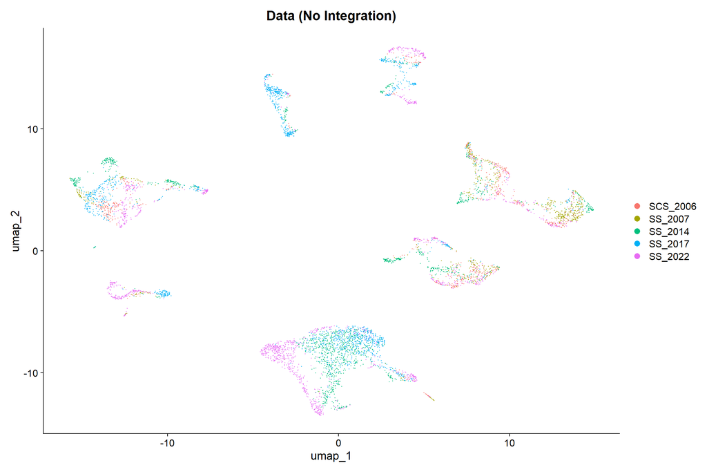

```r
plt_data <- DimPlot(obj_seurat, reduction = "umap", group.by = "donor_id") +
  ggtitle("Data (No Integration)")
print(plt_data)
```

# Harmony Integration

Harmony is a powerful tool for integrating single-cell data [@korsunsky2019fast].

Here are key settings:

```
* group.by.vars: Specifies variables for batch correction (e.g., "chemistry").
* theta: Controls correction strength. Higher values prioritize batch correction.
* lambda: Affects diversity preservation. Higher values emphasize within-group diversity.
* max.iter.harmony: Sets maximum iterations for convergence.
* epsilon.cluster: Controls clustering tolerance during integration.
```

The code runs Harmony integration on the dataset:

[output not shown]

Reminder: The data does not appear to need integration and unrequired integration can destroy biological data. This is merely an example of how to use Harmony to integrate by a given batch variable.

```r
obj_harmony <- RunHarmony(obj_seurat, group.by.vars = "donor_id")
```

```
## Transposing data matrix
```

```
## Initializing state using k-means centroids initialization
```

```
## Harmony 1/10
```

```
## Harmony 2/10
```

```
## Harmony 3/10
```

```
## Harmony 4/10
```

```
## Harmony converged after 4 iterations
```

```r
obj_harmony <- RunUMAP(obj_harmony, reduction = "harmony", dims = 1:30)
```

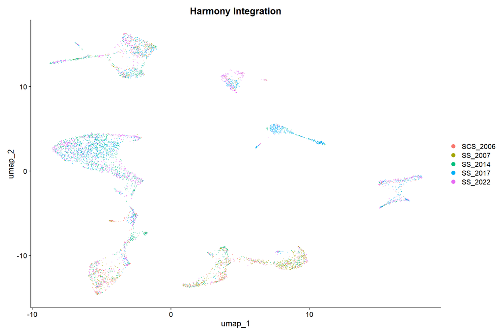

```r
plt_harmony <- DimPlot(obj_harmony, reduction = "umap", group.by = "donor_id") +
  ggtitle("Harmony Integration")
print(plt_harmony)
```

# RPCA Integration

Reciprocal PCA (RPCA) is a powerful method for integrating multiple single-cell RNA sequencing datasets. This section demonstrates how to perform RPCA integration using the Seurat package.

## Split the dataset

First, we split the Seurat object by donor ID and preprocess each subset:

```
Splits the Seurat object into a list of smaller objects, one per donor.
Normalizes the data for each donor using log-normalization.
Identifies highly variable features for each donor subset.
```

```r
lst_split_data <- SplitObject(obj_seurat, split.by = "donor_id")
lst_split_data <- lapply(lst_split_data, function(x) {
  x <- NormalizeData(x)
  x <- FindVariableFeatures(x)
  return(x)
})
```

## Perform RPCA integration

Reminder: The data does not appear to need integration and unrequired integration can destroy biological data. This is merely an example of how to use RPCA to integrate by a given batch variable.

Next, we perform the RPCA integration:

This process involves:

```
Selecting features to use for integration across all datasets.
Finding integration anchors using RPCA.
Integrating the data based on the identified anchors.
```

```r
vec_features <- SelectIntegrationFeatures(object.list = lst_split_data)
obj_rpca_anchors <- FindIntegrationAnchors(object.list = lst_split_data, anchor.features = vec_features, reduction = "rpca")
```

```
## Scaling features for provided objects
```

```
## Computing within dataset neighborhoods
```

```
## Finding all pairwise anchors
```

```
## Projecting new data onto SVD
## Projecting new data onto SVD
```

```
## Finding neighborhoods
```

```
## Finding anchors
```

```
##  Found 1072 anchors
```

```
## Projecting new data onto SVD
## Projecting new data onto SVD
```

```
## Finding neighborhoods
```

```
## Finding anchors
```

```
##  Found 1037 anchors
```

```
## Projecting new data onto SVD
## Projecting new data onto SVD
```

```
## Finding neighborhoods
```

```
## Finding anchors
```

```
##  Found 888 anchors
```

```
## Projecting new data onto SVD
## Projecting new data onto SVD
```

```
## Finding neighborhoods
```

```
## Finding anchors
```

```
##  Found 991 anchors
```

```
## Projecting new data onto SVD
## Projecting new data onto SVD
```

```
## Finding neighborhoods
```

```
## Finding anchors
```

```
##  Found 603 anchors
```

```
## Projecting new data onto SVD
## Projecting new data onto SVD
```

```
## Finding neighborhoods
```

```
## Finding anchors
```

```
##  Found 1416 anchors
```

```
## Projecting new data onto SVD
## Projecting new data onto SVD
```

```
## Finding neighborhoods
```

```
## Finding anchors
```

```
##  Found 1344 anchors
```

```
## Projecting new data onto SVD
## Projecting new data onto SVD
```

```
## Finding neighborhoods
```

```
## Finding anchors
```

```
##  Found 1033 anchors
```

```
## Projecting new data onto SVD
## Projecting new data onto SVD
```

```
## Finding neighborhoods
```

```
## Finding anchors
```

```
##  Found 1165 anchors
```

```
## Projecting new data onto SVD
## Projecting new data onto SVD
```

```
## Finding neighborhoods
```

```
## Finding anchors
```

```
##  Found 1413 anchors
```

```r
obj_rpca <- IntegrateData(anchorset = obj_rpca_anchors)
```

```
## Merging dataset 1 into 5
```

```
## Extracting anchors for merged samples
```

```
## Finding integration vectors
```

```
## Finding integration vector weights
```

```
## Integrating data
```

```
## Merging dataset 2 into 5 1
```

```
## Extracting anchors for merged samples
```

```
## Finding integration vectors
```

```
## Finding integration vector weights
```

```
## Integrating data
```

```
## Merging dataset 4 into 3
```

```
## Extracting anchors for merged samples
```

```
## Finding integration vectors
```

```
## Finding integration vector weights
```

```
## Integrating data
```

```
## Merging dataset 3 4 into 5 1 2
```

```
## Extracting anchors for merged samples
```

```
## Finding integration vectors
```

```
## Finding integration vector weights
```

```
## Integrating data
```

## Visualize RPCA integration

Finally, we process and visualize the integrated data:

[output not shown]

```r
obj_rpca <- ScaleData(obj_rpca)
obj_rpca <- RunPCA(obj_rpca)
```

```
## PC_ 1
## Positive:  TM4SF1, IFI27, JUNB, IFITM3, TIMP3, EPAS1, NHERF2, HLA-E, IRF1, SOCS3
##     RAMP2, EFNB2, HEXIM1, RNASE1, BST2, A2M, ID1, KLF2, CRIP2, CAVIN1
##     GNG11, GSN, PPP1R15A, NFKBIA, HLA-B, ICAM1, IGFBP5, CDKN1A, IFITM2, MEIS2
## Negative:  FXYD2, ALDOB, SMIM24, APOE, GATM, PDZK1IP1, SPP1, UGT2B7, HPD, MT1F
##     MGST1, GSTA1, GPX3, MT1H, LGALS2, MT1G, NAT8, CXCL14, BHMT, TMEM176A
##     DCXR, CLTRN, ALB, GLYAT, MIOX, DPEP1, ACSM2A, FABP1, ACSM2B, DDC
## PC_ 2
## Positive:  MAL, CLDN4, CA12, CD24, DEFB1, MUC1, CLCNKB, TNFRSF12A, ZNF165, TACSTD2
##     ELF3, TMEM213, MAL2, SCIN, PTGER3, HSD11B2, DMKN, ATP6V1B1, SDC4, CDH1
##     CKB, SCNN1A, KLF5, RHOBTB3, CLCNKA, WFDC2, TMPRSS2, ATP1B1, COBLL1, EPCAM
## Negative:  ALDOB, GATM, FTL, HPD, COTL1, RBP5, LGALS2, MT1G, MIOX, GSTA1
##     NAT8, GLYAT, GPX3, ASS1, MT1H, FABP1, ALB, PDZK1IP1, UGT2B7, DPEP1
##     HLA-DRA, BHMT, SRGN, HLA-DPA1, HLA-DRB1, DDC, HLA-DPB1, PRODH2, FBP1, AKR1C3
## PC_ 3
## Positive:  ADIRF, PDZK1IP1, GSTA1, MT1X, RBP5, ASS1, GPX3, GATM, FABP1, UGT2B7
##     NAT8, ALDOB, MIOX, MT1E, GLYAT, IGFBP4, MT1F, CXCL14, CALD1, MGST1
##     MT1G, HPD, DPEP1, FXYD2, SMIM24, BHMT, MT1H, APOE, PRODH2, ALB
## Negative:  TYROBP, FCER1G, BCL2A1, LST1, AIF1, IL1B, PLAUR, MS4A7, LYZ, LAPTM5
##     C15orf48, PLEK, CTSS, GPR183, SRGN, C5AR1, CCL3L3, CCL3, MS4A6A, CXCL8
##     SAMSN1, TNFAIP8, CCL4, MIR3945HG, CCL4L2, CD68, EREG, ENSG00000257764, SPI1, FCGR2A
## PC_ 4
## Positive:  SOD3, TAGLN, MYL9, BGN, CPE, GEM, FOXC2, SPRY2, TPM2, RGS5
##     FXYD1, MYC, ACTA2, FRZB, ACTN1, FHL2, AEBP1, RERGL, PTN, NOTCH3
##     ID4, MYH11, PLN, ECRG4, NUPR1, NTRK3, FOSL1, LAMC2, FSTL3, AXL
## Negative:  ATP6V1G3, ATP6V0D2, SLC4A1, DMRT2, ADGRF5, SLC26A7, ATP6V1C2, SRARP, HEPACAM2, TMEM213
##     FAM24B, CLNK, RHCG, ATP6V1B1, THRSP, KCNJ13, LINC01187, RHBG, ERP27, PSCA
##     CNTNAP5, ATP6V0A4, STAP1, SMIM6, PACRG, EXOSC7, CLDN8, SYT17, IGFBP5, DSG2
## PC_ 5
## Positive:  TAGLN, ACTA2, TPM2, FRZB, RGS5, FXYD1, RERGL, PLN, BGN, MYH11
##     NOTCH3, MYL9, LMOD1, MFGE8, FOXC2, NDUFA4L2, RCAN2, PLAC9, COL1A1, MFAP4
##     PPP1R12B, RGS16, CNN1, ECRG4, NTRK3, PDGFRB, SLC4A1, IRAG1, PGF, ATP6V1G3
## Negative:  LAMC2, TACSTD2, TFPI2, S100A2, S100A16, TCIM, EGOT, ITGB6, SPP1, S100A14
##     CLDN14, CLDN1, SFN, KLF5, PLAU, CHD9NB, WWTR1, SLC12A1, FOSL1, LIF
##     C1orf116, LAMB3, PPP1R1A, EMP1, SOX9, IL6ST, KCNJ1, PIGR, CLDN3, ACSL4
```

```r
obj_rpca <- RunUMAP(obj_rpca, dims = 1:30)
```

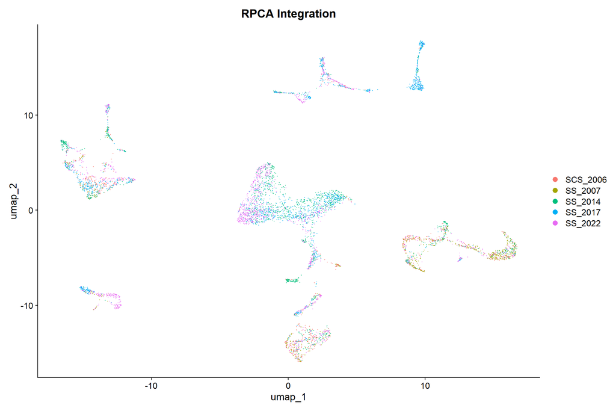

```r
plt_rpca <- DimPlot(obj_rpca, reduction = "umap", group.by = "donor_id") +
  ggtitle("RPCA Integration")
print(plt_rpca)
```

## Why Harmony Might Be Better Than Other Methods

```
1. Harmony vs. CCA (Canonical Correlation Analysis):

    * Harmony is faster and scales better with large datasets [@stuart2019comprehensive].

    * Handles complex batch structures more effectively.

2. Harmony vs. RPCA (Reciprocal PCA):

    * Harmony works well with non-linear relationships between datasets [@stuart2019comprehensive].

    * More flexible in handling various batch effects.

3. Harmony vs. scVI:
    * Harmony is computationally less demanding [@lopez2018deep].

    * Easier to use and tune, especially for those less familiar with deep learning.
```

# Evaluation of Integration Methods

To evaluate the effectiveness of integration methods, the code:

```
Calculates Local Inverse Simpson's Index (LISI) scores for both Harmony and RPCA integrations.
Summarizes and visualizes LISI scores for donor IDs and cell types.
```

## Visual Comparison

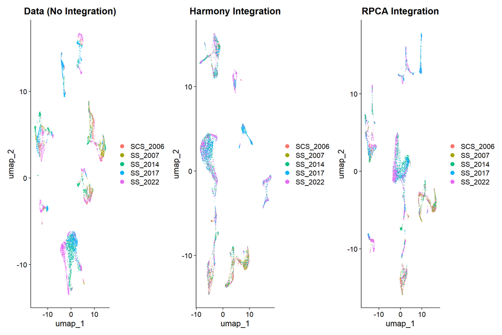

```r
plt_comparison <- plt_data + plt_harmony + plt_rpca
print(plt_comparison)
```

## Silhouette Score Analysis

Higher silhouette scores and mixing scores generally indicate better integration.

```
## Found more than one class "dist" in cache; using the first, from namespace 'spam'
```

```
## Also defined by 'BiocGenerics'
```

```
## Found more than one class "dist" in cache; using the first, from namespace 'spam'
```

```
## Also defined by 'BiocGenerics'
```

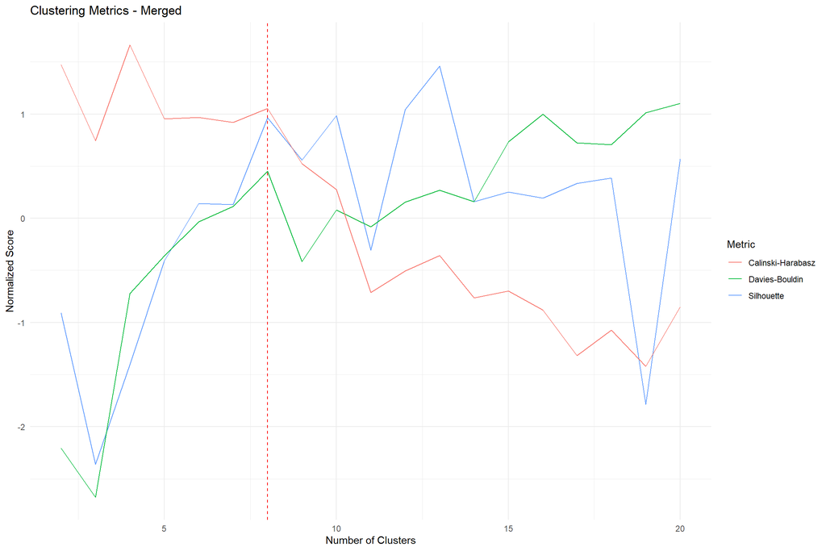

```
## Consensus cluster number (Merged): 8
## Agreement score (Merged): 0
```

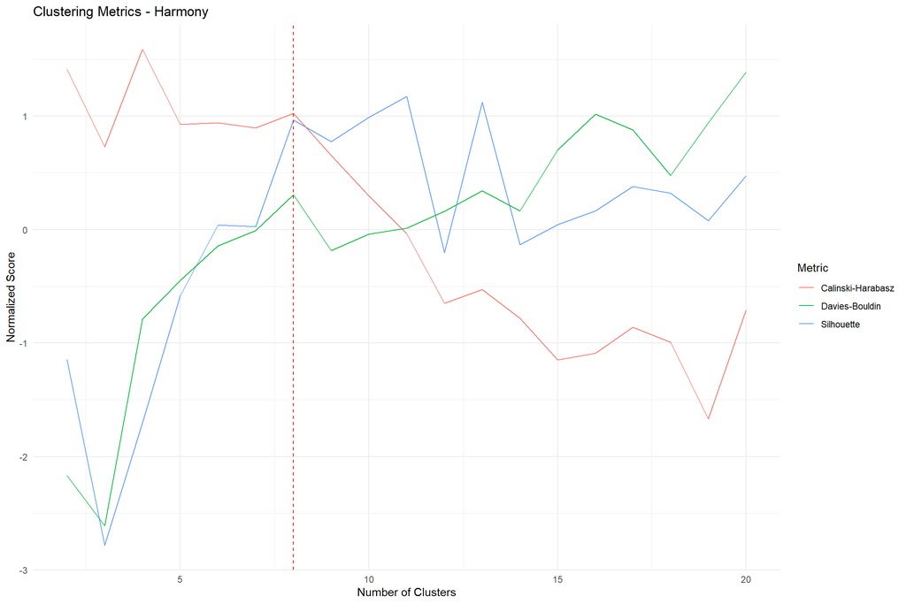

```
## Consensus cluster number (Harmony): 8
## Agreement score (Harmony): 0
```

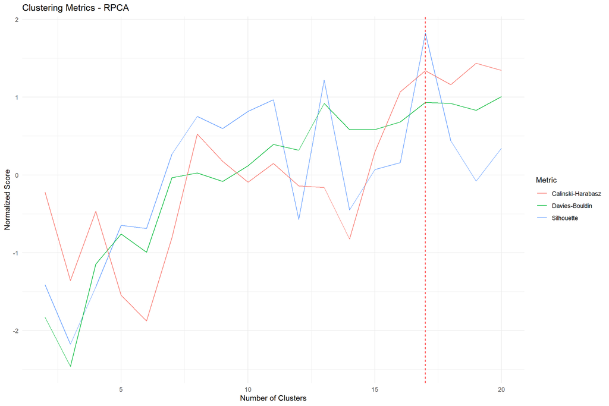

```
## Consensus cluster number (RPCA): 17
## Agreement score (RPCA): 0.33
```

```r
library(Seurat)
library(ggplot2)
library(cluster)
library(fpc)
library(fields)
library(lisi) # Implements the Local Inverse Simpson's Index (LISI) to assess the mixing of cells across categorical variables in single-cell datasets. Reference: https://github.com/immunogenomics/lisi
library(kneedle) # Provides a method for find the elbow point using the "knee" method https://github.com/etam4260/kneedle?tab=readme-ov-file

library(clusterSim) # Searching for optimal clustering procedure for a data set. https://cran.r-project.org/package=clusterSim

# Function to calculate clustering metrics
calculate_clustering_metrics <- function(obj_seurat, int_max_clusters = 20, vec_dims_use = 1:20) {
  mat_pca_coords <- Embeddings(obj_seurat, reduction = "pca")[, vec_dims_use]
  mat_dist_matrix <- as.matrix(dist(mat_pca_coords))

  lst_results <- lapply(2:int_max_clusters, function(k) {
    tryCatch({
      vec_clusters <- kmeans(mat_pca_coords, centers = k, nstart = 20)$cluster
      num_sil <- mean(silhouette(vec_clusters, mat_dist_matrix)[, 3])
      num_db <- index.DB(mat_pca_coords, vec_clusters)$DB
      num_ch <- calinhara(mat_pca_coords, vec_clusters)
      c(num_sil, num_db, num_ch)
    }, error = function(e) {
      message(sprintf("Error calculating metrics for k=%d: %s", k, e$message))
      c(NA, NA, NA)
    })
  })

  mat_results <- do.call(rbind, lst_results)
  colnames(mat_results) <- c("silhouette", "davies_bouldin", "calinski_harabasz")

  as.data.frame(mat_results)
}

# Function to determine consensus cluster number
determine_consensus <- function(df_metrics) {
  df_metrics$int_clusters <- 2:(nrow(df_metrics) + 1)

  df_metrics[, 1:3] <- scale(df_metrics[, 1:3])
  df_metrics$davies_bouldin <- -df_metrics$davies_bouldin  # Invert Davies-Bouldin index
  df_metrics$num_avg_score <- rowMeans(df_metrics[, 1:3])

  int_consensus_cluster <- df_metrics$int_clusters[which.max(df_metrics$num_avg_score)]

  vec_best_clusters <- c(
    which.max(df_metrics$silhouette) + 1,
    which.max(df_metrics$davies_bouldin) + 1,
    which.max(df_metrics$calinski_harabasz) + 1
  )
  num_agreement_score <- sum(vec_best_clusters == int_consensus_cluster) / 3

  list(
    int_consensus_cluster = int_consensus_cluster,
    num_agreement_score = num_agreement_score,
    df_metrics = df_metrics
  )
}

# Function to analyze and plot clustering results
analyze_clustering <- function(obj_seurat, chr_method) {
  int_max_clusters <- 20
  df_metrics <- calculate_clustering_metrics(obj_seurat, int_max_clusters = int_max_clusters)
  lst_consensus <- determine_consensus(df_metrics)

  plt_metrics <- ggplot(lst_consensus$df_metrics, aes(x = int_clusters)) +
    geom_line(aes(y = silhouette, color = "Silhouette")) +
    geom_line(aes(y = davies_bouldin, color = "Davies-Bouldin")) +
    geom_line(aes(y = calinski_harabasz, color = "Calinski-Harabasz")) +
    geom_vline(xintercept = lst_consensus$int_consensus_cluster, linetype = "dashed", color = "red") +
    labs(title = paste("Clustering Metrics -", chr_method),
         x = "Number of Clusters",
         y = "Normalized Score",
         color = "Metric") +
    theme_minimal()

  print(plt_metrics)

  cat(paste0("Consensus cluster number (", chr_method, "): ", lst_consensus$int_consensus_cluster, "\n"))
  cat(paste0("Agreement score (", chr_method, "): ", round(lst_consensus$num_agreement_score, 2), "\n\n"))

  return(lst_consensus)
}

# Analyze clustering for different integration methods
lst_results <- list(
  Merged = analyze_clustering(obj_seurat, "Merged"),
  Harmony = analyze_clustering(obj_harmony, "Harmony"),
  RPCA = analyze_clustering(obj_rpca, "RPCA")
)
```

### Interpretation of Silhouette Scores

```
Range: Silhouette scores typically range from -1 to +1.
Negative scores: Indicate that samples might be assigned to the wrong clusters.
Scores near zero: Suggest that samples are on or very close to the decision boundary between clusters.
Positive scores: Indicate that samples are well-matched to their clusters.
```

## Measuring Integration Effectiveness

To evaluate the effectiveness of integration methods, the code:

```
Calculates Local Inverse Simpson's Index (LISI) scores for both Harmony and RPCA integrations.
Summarizes and visualizes LISI scores for donor IDs and cell types.
```

To quantify the effectiveness of integration and detect over/under-integration, we can use the Local Inverse Simpson’s Index (LISI) [@korsunsky2019fast]:

### Calculate LISI scores

```r
# Load necessary libraries
library(ggplot2)

# Calculate LISI scores for the integrated data using different methods
lisi_scores_merge <- compute_lisi(
  X = Embeddings(obj_seurat, "umap"),
  meta_data = obj_seurat@meta.data,
  label_colnames = c("donor_id", "cell_type")
)

lisi_scores_harmony <- compute_lisi(
  X = Embeddings(obj_harmony, "umap"),
  meta_data = obj_harmony@meta.data,
  label_colnames = c("donor_id", "cell_type")
)

lisi_scores_rpca <- compute_lisi(
  X = Embeddings(obj_rpca, "umap"),
  meta_data = obj_rpca@meta.data,
  label_colnames = c("donor_id", "cell_type")
)
```

Here we have the summarize.

```r
# Summarize LISI scores for each dataset
summary_merge_donor <- summary(lisi_scores_merge$donor_id)
summary_merge_cell <- summary(lisi_scores_merge$cell_type)

summary_harmony_donor <- summary(lisi_scores_harmony$donor_id)
summary_harmony_cell <- summary(lisi_scores_harmony$cell_type)

summary_rpca_donor <- summary(lisi_scores_rpca$donor_id)
summary_rpca_cell <- summary(lisi_scores_rpca$cell_type)

# Print summaries
print(summary_merge_donor)
```

```
##    Min. 1st Qu.  Median    Mean 3rd Qu.    Max.
##   1.000   1.154   1.655   1.780   2.158   4.771
```

```r
print(summary_merge_cell)
```

```
##    Min. 1st Qu.  Median    Mean 3rd Qu.    Max.
##   1.000   1.000   1.000   1.085   1.040   2.955
```

```r
print(summary_harmony_donor)
```

```
##    Min. 1st Qu.  Median    Mean 3rd Qu.    Max.
##   1.010   2.178   2.661   2.683   3.185   4.897
```

```r
print(summary_harmony_cell)
```

```
##    Min. 1st Qu.  Median    Mean 3rd Qu.    Max.
##   1.000   1.000   1.000   1.086   1.044   3.008
```

```r
print(summary_rpca_donor)
```

```
##    Min. 1st Qu.  Median    Mean 3rd Qu.    Max.
##   1.007   1.891   2.406   2.428   2.945   4.883
```

```r
print(summary_rpca_cell)
```

```
##    Min. 1st Qu.  Median    Mean 3rd Qu.    Max.
##   1.000   1.000   1.000   1.077   1.033   4.117
```

### Visualize LISI scores

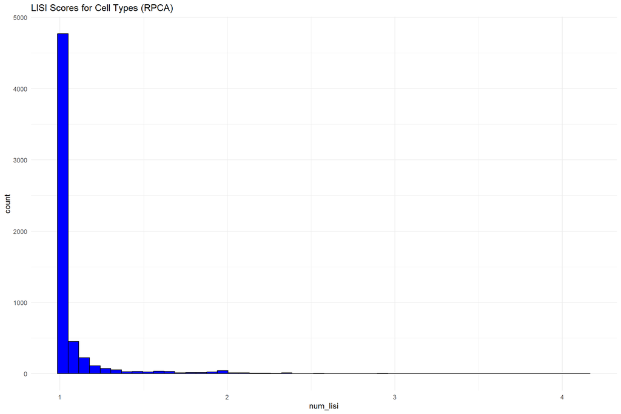

```r
# Visualize LISI scores distribution for cell types and donor IDs

# Function to create histogram plots
create_histogram <- function(data, title) {
  ggplot(data, aes(x = num_lisi)) +
    geom_histogram(bins = 50, fill = "blue", color = "black") +
    ggtitle(title) +
    theme_minimal()
}

# Prepare data frames for plotting
df_rpca_celltype <- data.frame(num_lisi = lisi_scores_rpca$cell_type)
df_rpca_donor <- data.frame(num_lisi = lisi_scores_rpca$donor_id)

# Plot LISI scores for cell types (RPCA)
plt_lisi_celltype <- create_histogram(df_rpca_celltype, "LISI Scores for Cell Types (RPCA)")
print(plt_lisi_celltype)
```

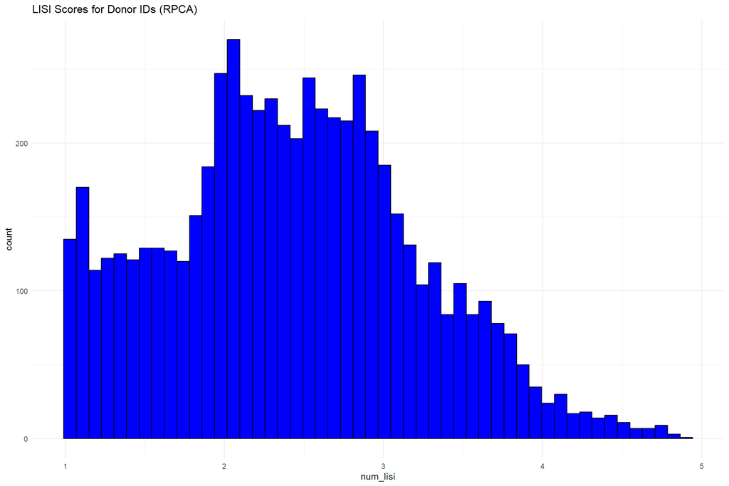

```r
# Plot LISI scores for donor IDs (RPCA)
plt_lisi_donor <- create_histogram(df_rpca_donor, "LISI Scores for Donor IDs (RPCA)")
print(plt_lisi_donor)
```

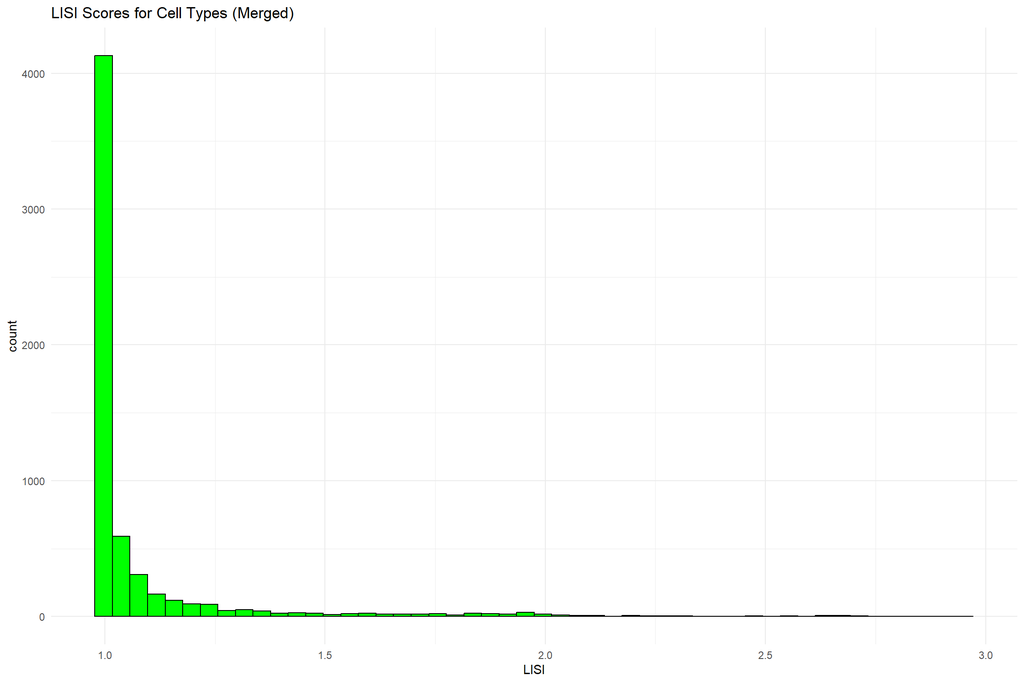

```r
# Additional plots for merged and harmony datasets
ggplot(data.frame(LISI = lisi_scores_merge$cell_type), aes(x = LISI)) +
  geom_histogram(bins = 50, fill = "green", color = "black") +
  ggtitle("LISI Scores for Cell Types (Merged)") +
  theme_minimal()
```

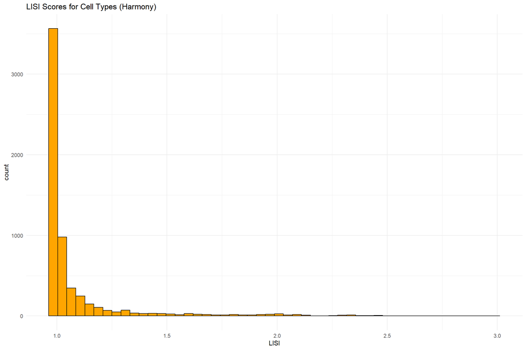

```r
ggplot(data.frame(LISI = lisi_scores_harmony$cell_type), aes(x = LISI)) +
  geom_histogram(bins = 50, fill = "orange", color = "black") +
  ggtitle("LISI Scores for Cell Types (Harmony)") +
  theme_minimal()
```

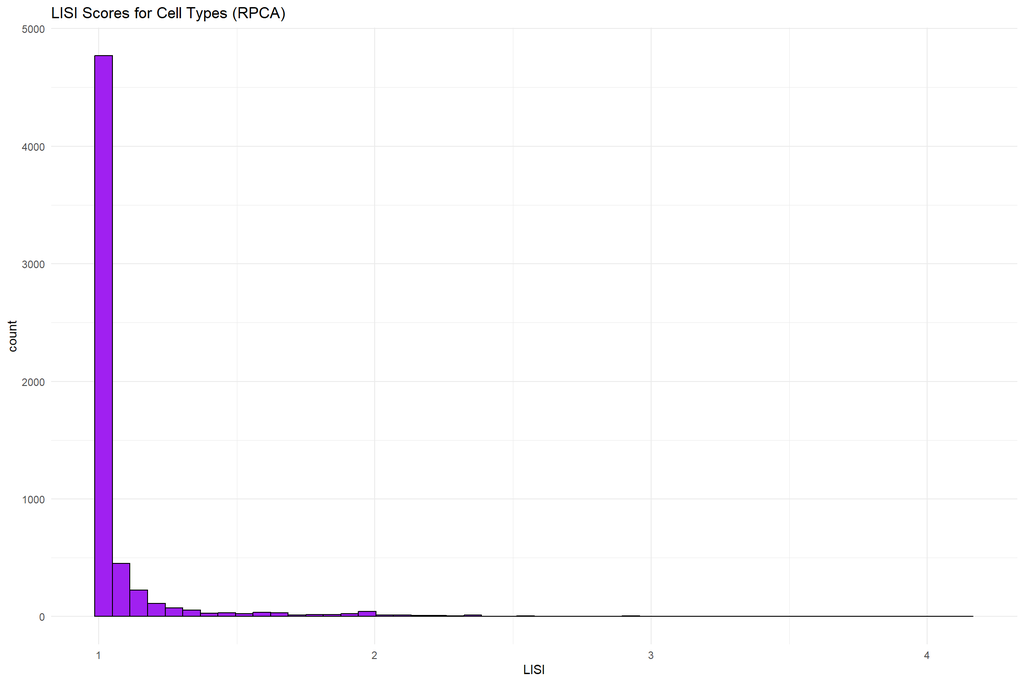

```r
ggplot(data.frame(LISI = lisi_scores_rpca$cell_type), aes(x = LISI)) +
  geom_histogram(bins = 50, fill = "purple", color = "black") +
  ggtitle("LISI Scores for Cell Types (RPCA)") +
  theme_minimal()
```

### Interpretation:

```
* LISI scores for batch variables (e.g., donor_id) should be close to the number of batches (perfect mixing).

* LISI scores for biological variables (e.g., cell_type) should be close to 1 (no mixing of different cell types).
```

# Conclusion

Based on the visual comparison, silhouette scores, and mixing metrics, you can determine which integration method performs best for your dataset.

Higher silhouette scores and mixing scores generally indicate better integration.

However, it’s important to also consider biological relevance and preservation of cell type-specific features when choosing the optimal integration method